# 18_tangent_get_opposite

## 18_tangent_get_opposite

#### Question

1. A right triangle has an angle of 0.67 radians. The adjacent leg has a length of 34 meters. How long, in meters, is the leg opposite the angle?

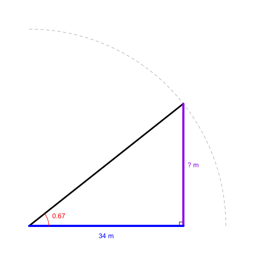

   Please round your answer to the nearest meter.

#### Question

2. A right triangle has an angle of 0.94 radians. The adjacent leg has a length of 54 meters. How long, in meters, is the leg opposite the angle?

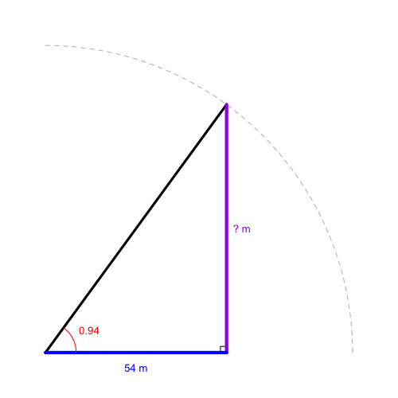

   Please round your answer to the nearest meter.

#### Question

3. A right triangle has an angle of 0.62 radians. The adjacent leg has a length of 73 meters. How long, in meters, is the leg opposite the angle?

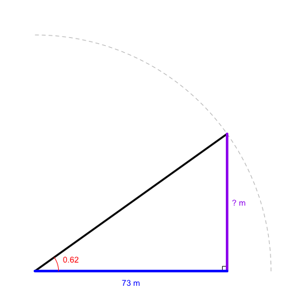

   Please round your answer to the nearest meter.

#### Question

4. A right triangle has an angle of 1.25 radians. The adjacent leg has a length of 22 meters. How long, in meters, is the leg opposite the angle?

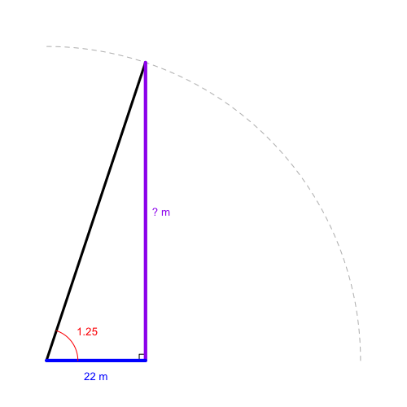

   Please round your answer to the nearest meter.

#### Question

5. A right triangle has an angle of 0.62 radians. The adjacent leg has a length of 22 meters. How long, in meters, is the leg opposite the angle?

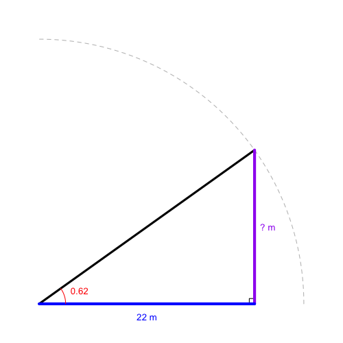

   Please round your answer to the nearest meter.

#### Question

6. A right triangle has an angle of 1.03 radians. The adjacent leg has a length of 23 meters. How long, in meters, is the leg opposite the angle?

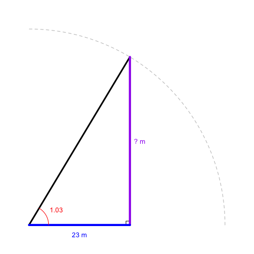

   Please round your answer to the nearest meter.

#### Question

7. A right triangle has an angle of 1.10 radians. The adjacent leg has a length of 25 meters. How long, in meters, is the leg opposite the angle?

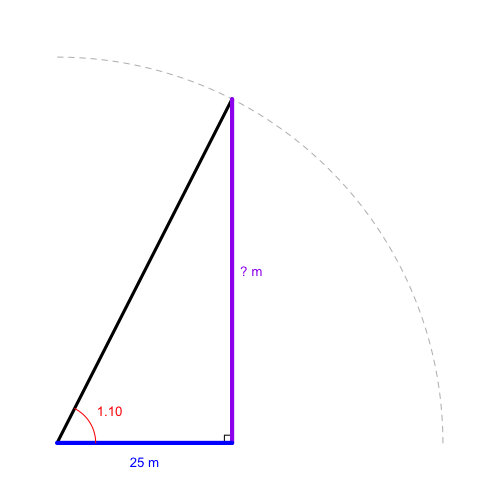

   Please round your answer to the nearest meter.

#### Question

8. A right triangle has an angle of 1.06 radians. The adjacent leg has a length of 48 meters. How long, in meters, is the leg opposite the angle?

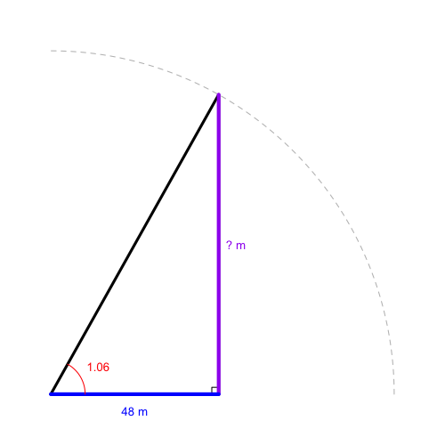

   Please round your answer to the nearest meter.